# 2016 Presidential Campaign Finance by Megan O’Neil

## State by candidate

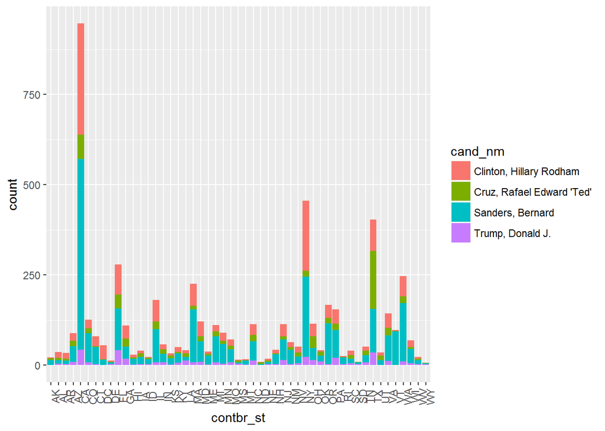

```r
# Using 'finalists' dataset from above, with top 4 candidates to create dataset primaries only:
finalists_primaries <- finalists[ which(finalists$contb_receipt_dt <= sanders_drop),]
#max(finalists_primaries$contb_receipt_dt)

ggplot(aes(x = contbr_st, fill = cand_nm), data = finalists_primaries) +
    geom_bar() +
    theme(axis.text.x = element_text(angle = 90))
```

Sanders appears to be beating Hilary in contributions in almost every state. Let’s look at just the two of them.

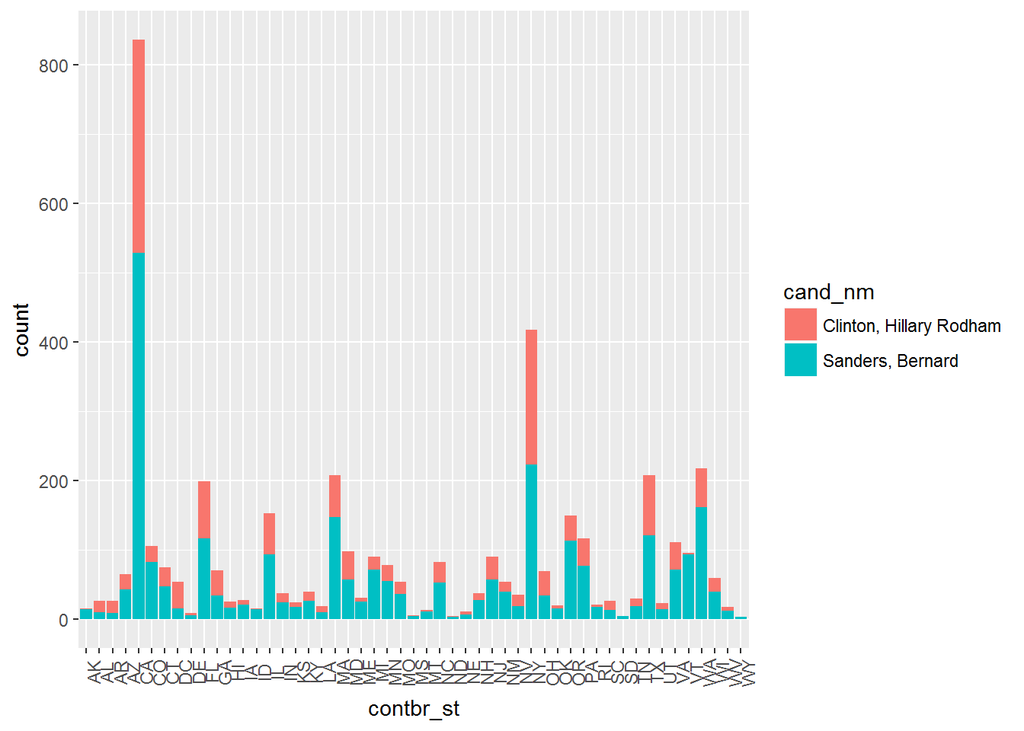

```r
dem_finalists_primaries <- finalists_primaries[ which(finalists_primaries$cand_nm == clinton_nm |
                                                finalists_primaries$cand_nm == sanders_nm),]
#max(finalists_primaries$contb_receipt_dt)

ggplot(aes(x = contbr_st, fill = cand_nm), data = dem_finalists_primaries) +
    geom_bar() +
    theme(axis.text.x = element_text(angle = 90))
```

How about just among republicans

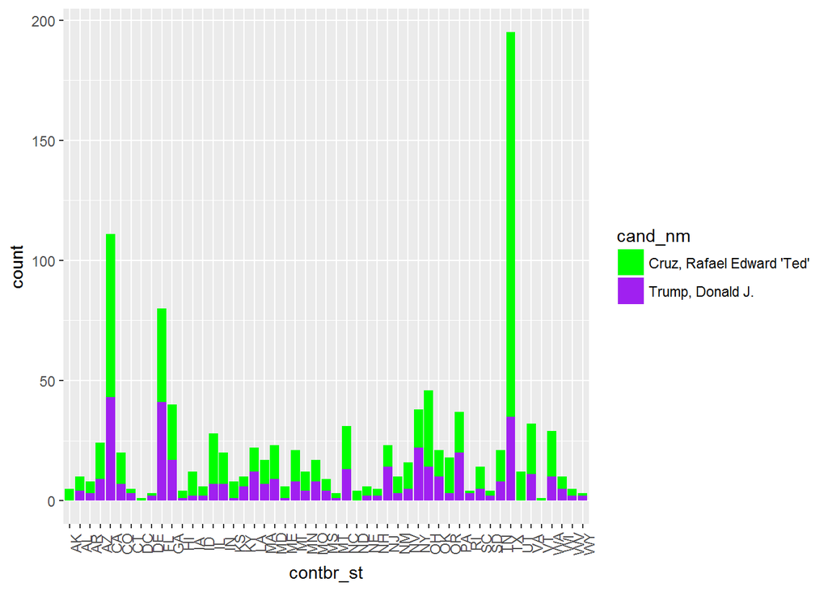

```r
rep_finalists_primaries <- finalists_primaries[ which(finalists_primaries$cand_nm == cruz_nm |
                                                finalists_primaries$cand_nm == trump_nm),]
#max(finalists_primaries$contb_receipt_dt)

ggplot(aes(x = contbr_st, fill = cand_nm), data = rep_finalists_primaries) +
    scale_fill_manual(values = c("green", "purple"))+
    geom_bar() +
    theme(axis.text.x = element_text(angle = 90))
```

```r
View(head(dem_finalists_primaries))

# First, create dataset by state and candidate name
finalists_primaries.by_state_cand <- finalists_primaries %>%
    group_by(contbr_st, cand_nm) %>%
    summarise(mean_contb = mean(contb_receipt_amt),
              median_contb = median(contb_receipt_amt),
              n = n()) %>%
    arrange(contbr_st, cand_nm)


finalists_primaries.by_state_cand.widetidy <- spread(subset(finalists_primaries.by_state_cand,
                                                            select = c('contbr_st', 'cand_nm', 'n')), cand_nm, n)

# rename columns
names(finalists_primaries.by_state_cand.widetidy) <- c('contbr_st','Clinton', 'Cruz','Sanders','Trump')
head(finalists_primaries.by_state_cand.widetidy)
```

```
## Source: local data frame [6 x 5]
## Groups: contbr_st [6]
##
##   contbr_st Clinton  Cruz Sanders Trump
##      <fctr>   <int> <int>   <int> <int>
## 1        AK       2     5      14    NA
## 2        AL      16     6      10     4
## 3        AR      17     5       9     3
## 4        AZ      22    15      43     9
## 5        CA     308    68     528    43
## 6        CO      24    13      82     7
```

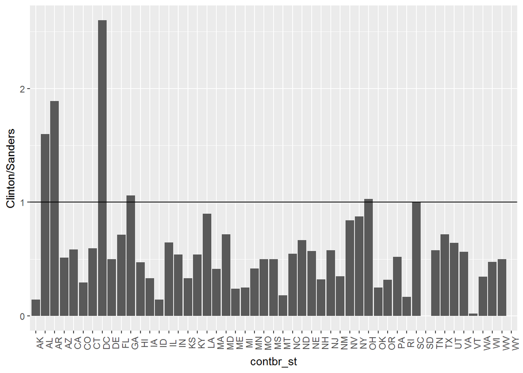

```r
# Chart ratio of Clinton to Sanders givers.
clinton_sanders <- ggplot(aes(x = contbr_st, y = Clinton/Sanders), data = finalists_primaries.by_state_cand.widetidy) +
    geom_bar(stat = 'identity') +
    theme(axis.text.x = element_text(angle = 90)) +
    geom_hline(yintercept = 1)

#horiztonal line reference: http://docs.ggplot2.org/0.9.3.1/geom_hline.html

clinton_sanders
```

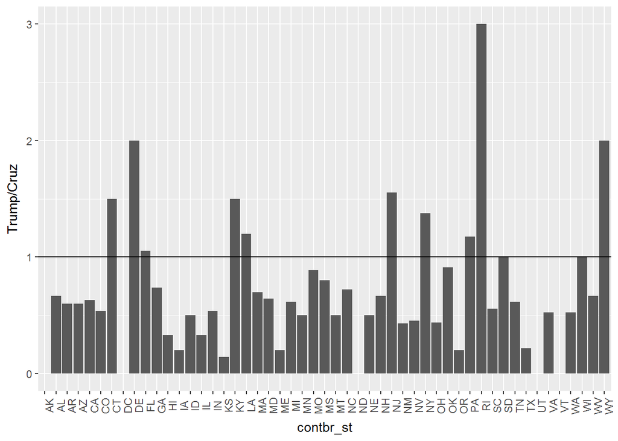

```r
# Chart ratio of Trump to Cruz givers.
trump_cruz <- ggplot(aes(x = contbr_st, y = Trump/Cruz), data = finalists_primaries.by_state_cand.widetidy) +
    geom_bar(stat = 'identity') +
    theme(axis.text.x = element_text(angle = 90)) +
    geom_hline(yintercept = 1)
trump_cruz
```

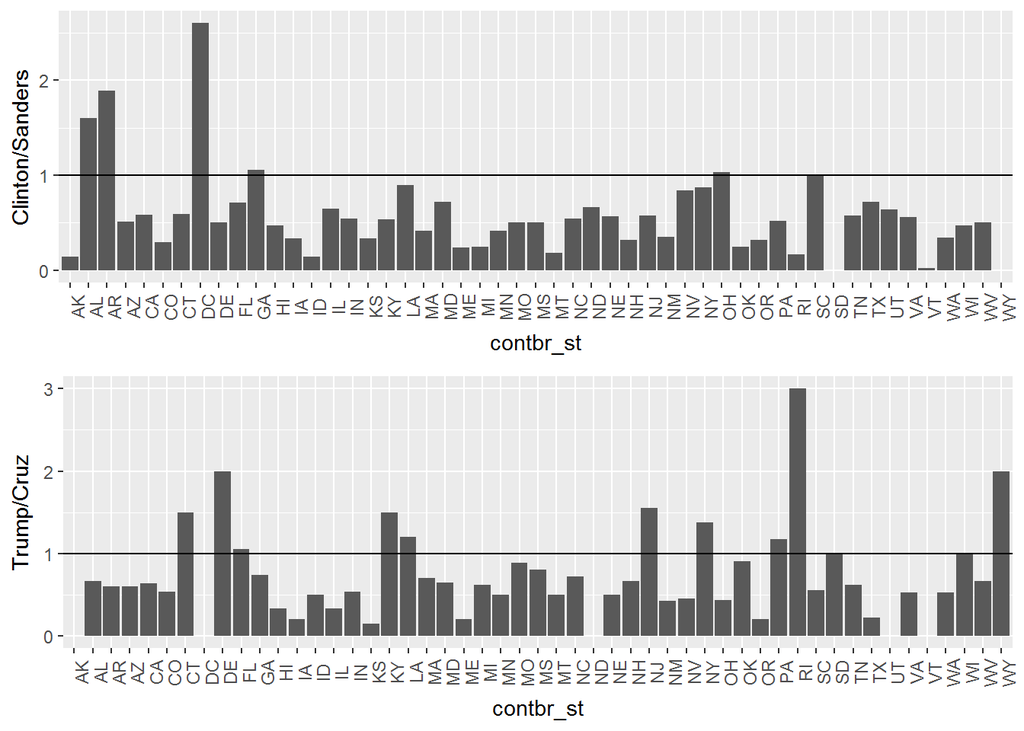

```r
grid.arrange(clinton_sanders ,trump_cruz)
```

## Size by candidate by party

I’m curious to see a box and whisker plot for campaign contribution size by candidate, colored by political party.

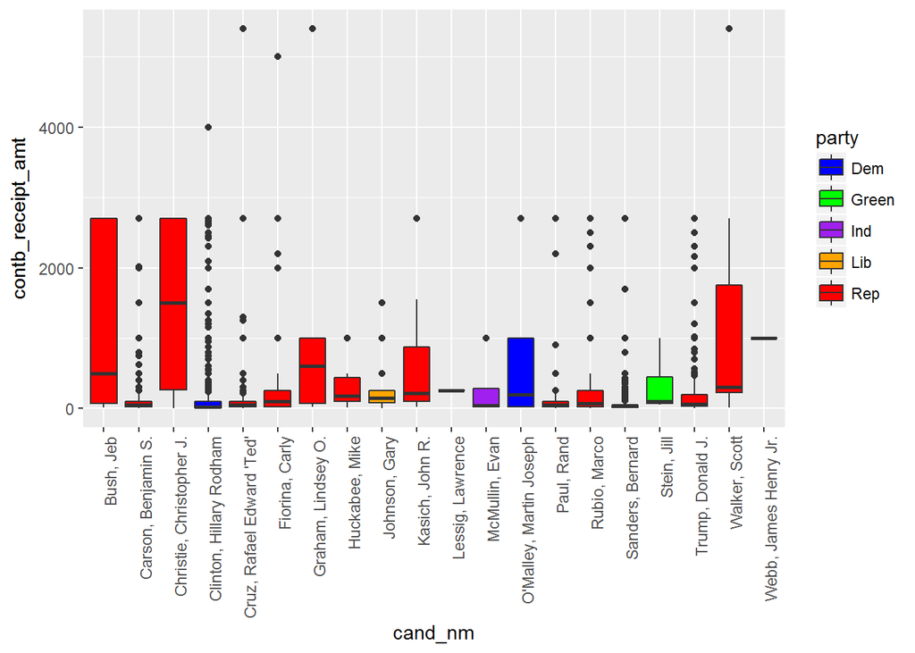

```r
ggplot(data = us_samp.clean, aes(x = cand_nm, y = contb_receipt_amt, fill = party))+
    scale_fill_manual(values=c("blue", "green", "purple", " orange", "red"))+
    geom_boxplot()+
    theme(axis.text.x = element_text(angle = 90, hjust = 1))
```

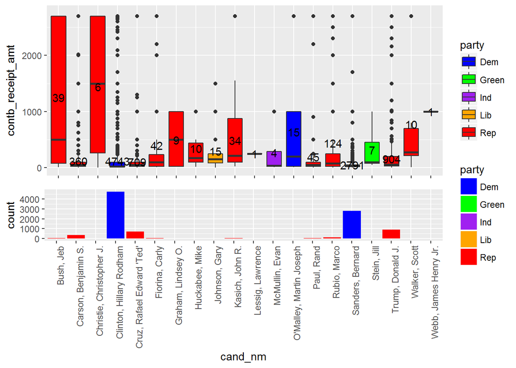

```r
# I want to add the number of contributions for each party
## Reference: http://stackoverflow.com/questions/3483203/create-a-boxplot-in-r-that-labels-a-box-with-the-sample-size-n
give.n <- function(x){
   return(c(y = mean(x), label = length(x)))
}

# Let's cut off some outliers to see it a bit more clearly.
contb_by_cand <- ggplot(data = us_samp.clean, aes(x = cand_nm, y = contb_receipt_amt, fill = party))+
    scale_fill_manual(values=c("blue", "green", "purple", " orange", "red"))+
    geom_boxplot()+
    theme(axis.text.x = element_text(angle = 90, hjust = 1))+
    scale_y_continuous(limits = c(0,2750))+
    stat_summary(fun.data = give.n, geom = "text") # add number of contributions by party


# This isn't all that helpful, I'm just going to show it together with a plot below demonstrating the number of contributions per candidate
num_cont <- ggplot(data = us_samp.clean,
                   aes(x = cand_nm, fill = party))+
    geom_bar()+
    scale_fill_manual(values=c("blue", "green", "purple", " orange", "red"))+
    theme(axis.text.x = element_text(angle = 90, hjust = 1))

grid.arrange(contb_by_cand +
  theme(axis.title.x=element_blank(),
        axis.text.x=element_blank()),
  num_cont)
```

OK, it’s smushed, but it demonstrates the difference. Those with the most contributions also had lower averages. Makes sense. Those who dropped out earlier had higher medians, with much higher variance, because there were fewer giving.

I want to do it for just Sanders, Clinton, Trump, and Cruz during the primaries.

```r
# Using 'finalists' dataset for 4 finalists, thru general election.
finalists_primaries <- finalists[which(finalists$contb_receipt_dt <= as.Date("2016-07-12")),]

max(finalists_primaries$contb_receipt_dt)
```

```
## [1] "2016-07-12"
```

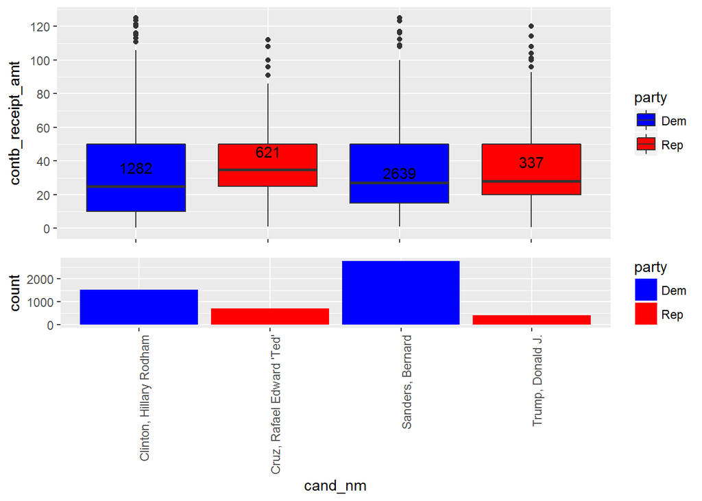

```r
contb_by_cand <- ggplot(data = finalists_primaries, aes(x = cand_nm,
                                              y = contb_receipt_amt, fill = party))+
    scale_fill_manual(values=c("blue", "red"))+
    geom_boxplot()+
    theme(axis.text.x = element_text(angle = 90, hjust = 1))+
    scale_y_continuous(limits = c(0,125), breaks = seq(0,120,20))+
    stat_summary(fun.data = give.n, geom = "text")

num_cont <- ggplot(data = finalists_primaries,
                   aes(x = cand_nm, fill = party))+
    geom_bar()+
    scale_fill_manual(values=c("blue", "red"))+
    theme(axis.text.x = element_text(angle = 90, hjust = 1))

grid.arrange(contb_by_cand +
  theme(axis.title.x=element_blank(),
        axis.text.x=element_blank()),
  num_cont)
```

In both parties, the candidates with the most contributions did not win the primary.

Let’s do one just by party.

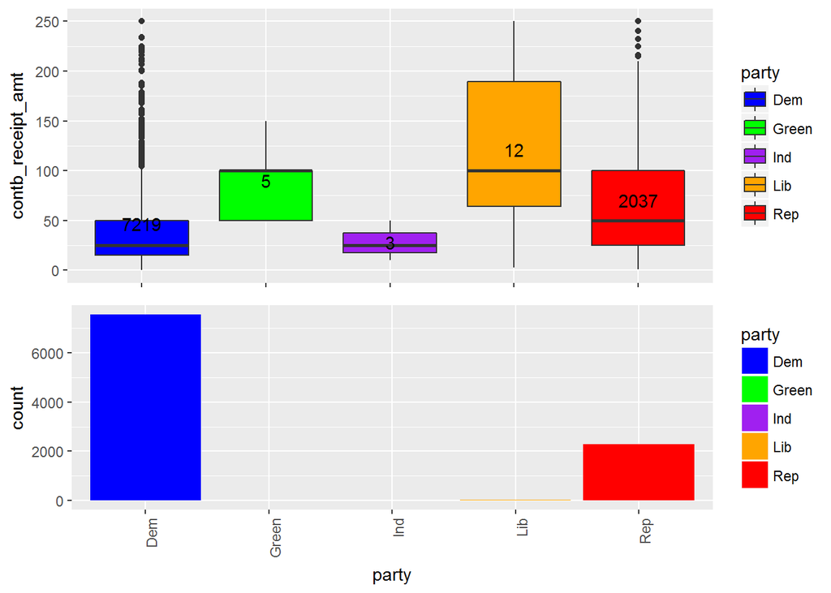

```r
contb_by_party <- ggplot(data = us_samp.clean, aes(x = party, y = contb_receipt_amt, fill = party))+
    scale_fill_manual(values=c("blue", "green", "purple", " orange", "red"))+
    geom_boxplot()+
    theme(axis.text.x = element_text(angle = 90, hjust = 1))+
    stat_summary(fun.data = give.n, geom = "text")+
    scale_y_continuous(limits = c(0,250))

num_cont_by_party <- ggplot(data = us_samp.clean,
                   aes(x = party, fill = party))+
    geom_bar()+
    scale_fill_manual(values=c("blue", "green", "purple", " orange", "red"))+
    theme(axis.text.x = element_text(angle = 90, hjust = 1))

grid.arrange(contb_by_party +
  theme(axis.title.x=element_blank(),
        axis.text.x=element_blank()),
  num_cont_by_party)
```

By party overall - including all primary candidates and including data through the general - contributions to democrats maintained around $25, while contributions to republicans increased to over $50. The median contribution for other parties is likely not that representative with so few data points.

# Multivariate Analysis

### Talk about some of the relationships you observed in this part of the investigation. Were there features that strengthened each other in terms of looking at your feature(s) of interest?

I looked at the number and size of contributions to each candidate over time, by party, and by state.

I ended up focusing charts on the top 4 candidates, because the other candidates often did not have enough data to draw meaningful observations from the sample.

I enjoyed making map visualiziations of the data, but this was not as useful to look at my primary interest of viewing the difference in contribution amount and size between candidates.

### Were there any interesting or surprising interactions between features?

I was somewhat surprised by the very distinct paths of contribution size to each candidate over time. As Clinton’s support went from large contributions to many small; Trump’s went from few small size then made a jump to larger contributions once the primaries were over.

It was also interesting to view in boxplot form how Democrats rely on numerous smaller donations, and Republicans get more big dollar donors. While the mean contribution size was not that distinct, it was different, and the number of contributions for the top two democratic candidates far exceeded the number of contributions for the top two republican candidates.

Finally, the state-wise analysis demonstrated how prevalent it was by state for the candidate in each party who did not win the primary to receive more contributions. We already saw that these candidates (Sanders and Cruz) got more overall candidates, the bar plots by state demonstrating the ratio of votes showed that this was the case in most states for both parties (43 for democrats, 35 for Republicans).

### OPTIONAL: Did you create any models with your dataset? Discuss the strengths and limitations of your model.

# Final Plots and Summary

### Plot One: Top Candidates Number of Contributions Over Time

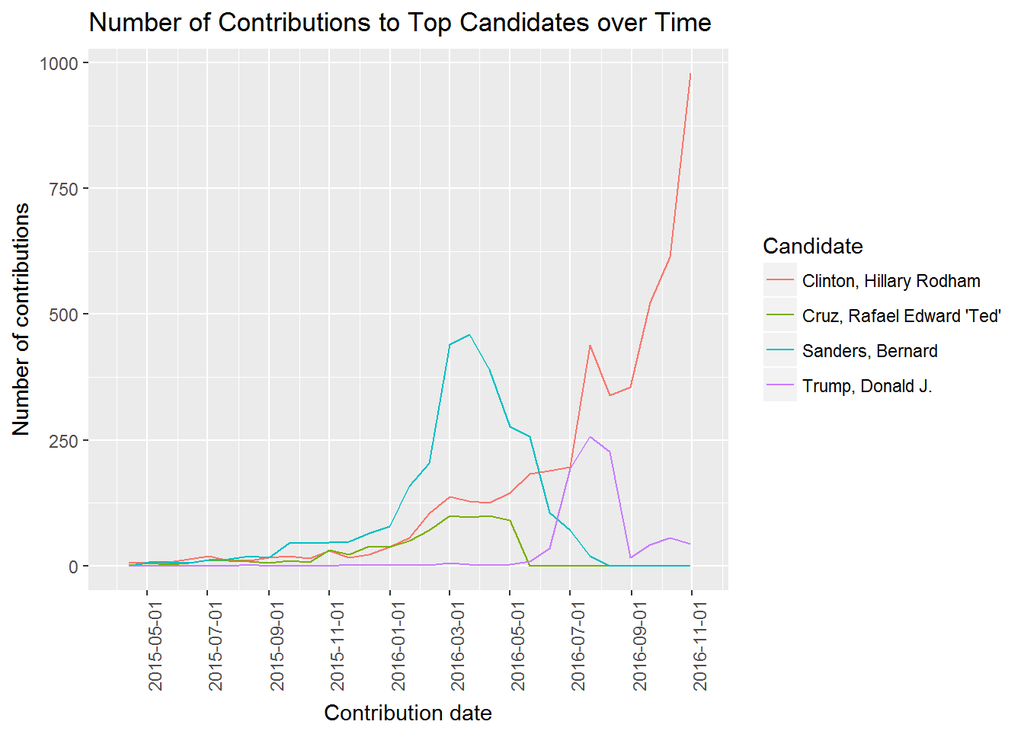

### Description One

Note that the acutal number of contributions demonstrated in this chart reflects a sample of total overall contributions.

### Plot Two

[figure not shown]

### Description Two

The average contribution size over time followed a similar pattern for Clinton, Sanders, and Cruz; with higher average amounts at the start of the race. This was much more pronouned for Clinton, whose initial average contribution size was over $1200, compared to Sanders whose initial average contribution size was around $250. While Cruz had a jump around October2015, these three candidates generally had their average donation size fall througout the course of the campaign.

Trump, on the other hand, a notably unconventional candidate, started receiving contributions late, with his average contribution size at about the lowest it was throughout the race. His average size increased dramatically when the race dropped to just Trump and clinton.

### Plot Three

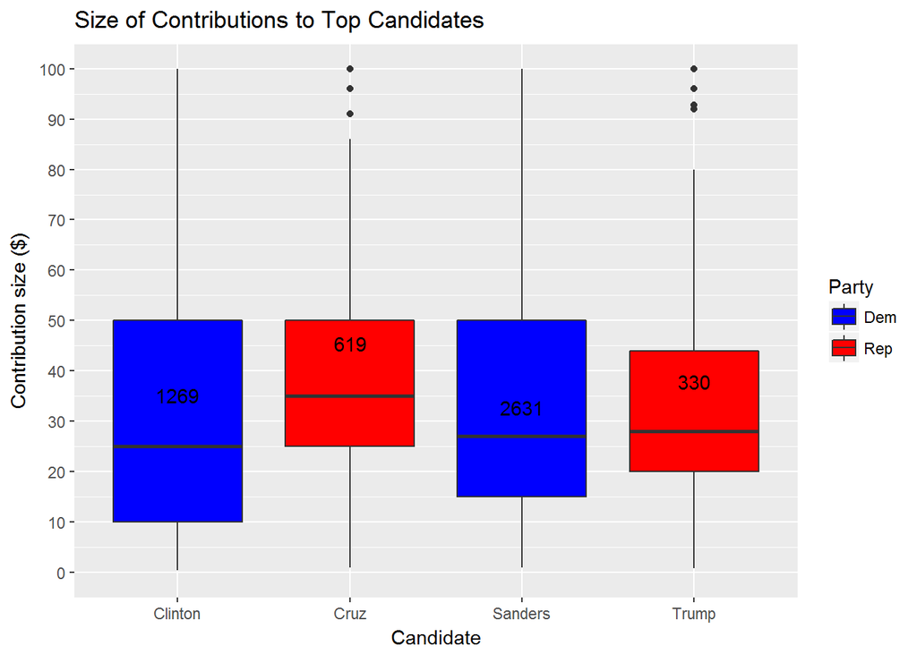

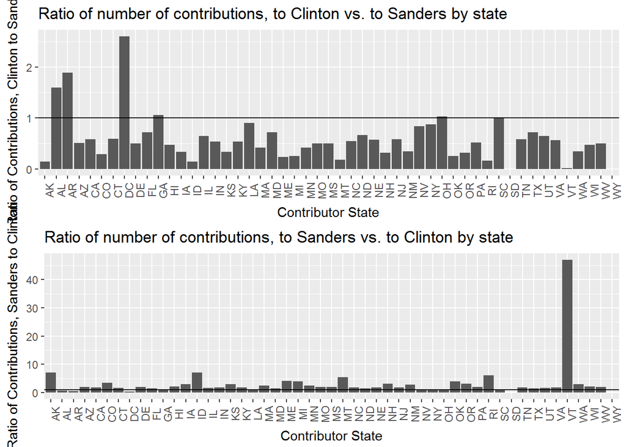

### Description Three

The top chart shows the ratios more clearly, with DC having the highest ratio of Clinton to Sanders, where about 2.5 times as many people contributed to Clinton as to Sanders.

However the bottom chart demonstrates one noteworthy state, Vermont, in which over 45 times as many contributions were made to Sanders as to Clinton.

# Reflection

## Where did I run into difficulties in the analysis?

In general, I ran into difficulties assessing the best methods to assess the data, and what subsets to use to do so. I was very interested in looking at a sample of the entire country, rather than simply one state. This required a sample, which cauesd some limitations in my analysis. For example, there were only a handful of contributions to candidates from parties that weren’t Democratic or Republican, which made it difficult to draw conculsions on average sample size or trends in dates of contributions.

So I decided to subset the data to the four top candidates. I also decided that I should further subset the data in some cases to the primaries, so that I could draw a relatively more even comparison between the number of contributions for candidates, since using the full dataset favored the candidates who went on to the general election and continued collecting contributions.

Ensuring throughout that my subsetting was working appropriately was surprisingly challenging, but instilled some better practices in naming data subsets.

## Where did I find successes?

I found sucess in assessing how contributions–numbers as well as mean/median size– changed over time using the date. After converting the contriubtion receipt date to a date object, this was a very valuable variable in assesing trends over time. I think the most fascinating aspect was how different Trump’s contribution distribution over time varied from the other top candidates, as demonstrated in plots 1 and 2 above in the final plots section.

## How could the analysis be enriched in future work (e.g. additional data and analyses)?

I think it would be fascinating to see over different election cycles how these trends play out. Most in the US see Trump as an extremely unusual candidate, who won in spite of incredible odds against him (according to most analysts). In this election, the andidates from both major parties that went on to the general election had far fewer contributions than their runner-ups, a trend that was present in the majority of states. I would be curious how common this is.

I am also curious over time if Republicans have always had higher contribution sizes and fewer contributions than democrats. If that has been present for recent history and if the difference is increasing or decreasing.